# Practical Machine Learning Project

### Feature selection

The following code was used to perform forward selection using the cross-validation error as the measure for feature selection:

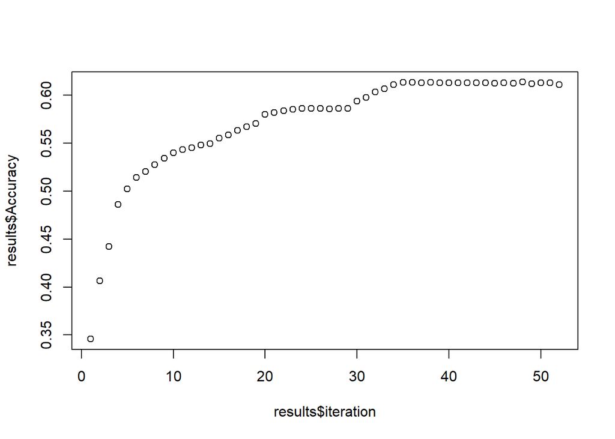

```
##     X iteration model        predictor  Accuracy
## 1  25         1    28    pitch_forearm 0.3458363
## 2  91         2    13    magnet_belt_z 0.4066356
## 3 106         3    48 accel_dumbbell_y 0.4424615
## 4 154         4    49 accel_dumbbell_z 0.4861891
## 5 227         5    24     magnet_arm_x 0.5022939
## 6 271         6    27     roll_forearm 0.5144746
```

```r
{
LDAdata <- data.frame()
for(i in 1:(ncol(Training)-1)){
  dat =data.frame(iteration = rep(i,(ncol(Training)-i)),
                  model = (ncol(Training) - i):1)
  LDAdata  = rbind(LDAdata,dat)

}

predlist <- 1:(ncol(Training)-1)
selected <- c()
results <- data.frame()
for(i in 1:(((ncol(Training)-1)*ncol(Training))/2)){

  ldaFit <- train(classe ~., data = Training[,c(selected,predlist[LDAdata[i,"model"]],53)]
                  , method = "lda"
                  ,trControl = trainControl(method = "cv"))
  LDAdata[i,"predictor"] = predictors[predlist[LDAdata[i,"model"]]]
  LDAdata[i,"Accuracy"] = ldaFit$results["Accuracy"]

  if (LDAdata[i,"model"] == 1) {
    iteration = LDAdata[i,"iteration"]
    candidates = LDAdata[LDAdata$iteration == iteration,]
    bestPred = candidates[which.max(candidates$Accuracy),"model"]
    selected = c(selected,bestPred)
    results = rbind(results,candidates[which.max(candidates$Accuracy),])
  }
}
plot(results$iteration,results$Accuracy)
head(results)
}
```

### Best LDA Model Results

Looking at the estimated test accuracy as more predictors are added in shows that there is very little gain in accuracy after 34 predictors. Adding additional predictors could lead to overtraining. As a result, the first 34 predictors were used to create an LDA model which had the following results:

```r
predictors = results[1:34,"predictor"]
ldaFit <- train(classe ~., data = Training[,c(predictors,"classe")], method = "lda"
                ,trControl = trainControl(method = "cv"))
ldaFit
```

```
## Linear Discriminant Analysis
##
## 19622 samples
##    34 predictor
##     5 classes: 'A', 'B', 'C', 'D', 'E'
##
## No pre-processing
## Resampling: Cross-Validated (10 fold)
## Summary of sample sizes: 17660, 17660, 17662, 17660, 17659, 17660, ...
## Resampling results:
##
##   Accuracy   Kappa
##   0.6107965  0.5058316
```

```r
predictions <- predict(ldaFit,newdata = Training[,c(predictors)])
confusionMatrix(predictions,as.factor(Training$classe))
```

```
## Confusion Matrix and Statistics
##
##           Reference
## Prediction    A    B    C    D    E
##          A 4036  511 1033  357  304
##          B  243 2429  496  180  735
##          C  481  473 1604  309  362
##          D  786  233  235 2165  422
##          E   34  151   54  205 1784
##
## Overall Statistics
##
##                Accuracy : 0.6125
##                  95% CI : (0.6056, 0.6193)
##     No Information Rate : 0.2844
##     P-Value [Acc > NIR] : < 2.2e-16
##
##                   Kappa : 0.508
##
##  Mcnemar's Test P-Value : < 2.2e-16
##
## Statistics by Class:
##
##                      Class: A Class: B Class: C Class: D Class: E
## Sensitivity            0.7233   0.6397  0.46873   0.6732  0.49459
## Specificity            0.8430   0.8955  0.89969   0.8978  0.97228
## Pos Pred Value         0.6467   0.5949  0.49675   0.5637  0.80072
## Neg Pred Value         0.8846   0.9120  0.88910   0.9334  0.89519
## Prevalence             0.2844   0.1935  0.17440   0.1639  0.18382
## Detection Rate         0.2057   0.1238  0.08174   0.1103  0.09092
## Detection Prevalence   0.3181   0.2081  0.16456   0.1957  0.11355
## Balanced Accuracy      0.7831   0.7676  0.68421   0.7855  0.73343
```

The Cross-validation accuracy is approximately 61% and the training accuracy is 61%. This is far too low to pass the quiz which requires an 80% or higher. The model does warn that there are collinear variables but the LDA assumptions may not work well for this data set.

## GBM Model

Since the LDA model accuracy isn't high enough, a gradient boosting model may yield better results and if not, it could be blended with the LDA and an additional model to achieve the desired accuracy. The gbm model was set using the following code:

```r
modelFit <- train(classe ~., data = Training, method = "gbm",
                  trControl = trainControl(method = "cv"))
modelFit
predictions <- predict(modelFit,newdata = Training)
predictions
confusionMatrix(predictions,as.factor(Training$classe))
```

```
## Stochastic Gradient Boosting
##
## 19622 samples
##    52 predictor
##     5 classes: 'A', 'B', 'C', 'D', 'E'
##
## No pre-processing
## Resampling: Cross-Validated (10 fold)
## Summary of sample sizes: 17660, 17660, 17660, 17660, 17660, 17660, ...
## Resampling results across tuning parameters:
##
##   interaction.depth  n.trees  Accuracy   Kappa
##   1                   50      0.7518585  0.6854092
##   1                  100      0.8208644  0.7732484
##   1                  150      0.8548570  0.8163272
##   2                   50      0.8557760  0.8172780
##   2                  100      0.9076056  0.8830819
##   2                  150      0.9328330  0.9150096
##   3                   50      0.8979223  0.8707768
##   3                  100      0.9436868  0.9287508
##   3                  150      0.9634096  0.9537090
##
## Tuning parameter 'shrinkage' was held constant at a value of 0.1
##
## Tuning parameter 'n.minobsinnode' was held constant at a value of 10
## Accuracy was used to select the optimal model using the largest value.
## The final values used for the model were n.trees = 150, interaction.depth =
##  3, shrinkage = 0.1 and n.minobsinnode = 10.
```

```
## Confusion Matrix and Statistics
##
##           Reference
## Prediction    A    B    C    D    E
##          A 5527   86    0    1    4
##          B   35 3642   88    8   25
##          C   12   69 3298   85   24
##          D    4    0   32 3109   39
##          E    2    0    4   13 3515
##
## Overall Statistics
##
##                Accuracy : 0.9729
##                  95% CI : (0.9706, 0.9752)
##     No Information Rate : 0.2844
##     P-Value [Acc > NIR] : < 2.2e-16
##
##                   Kappa : 0.9658
##
##  Mcnemar's Test P-Value : < 2.2e-16
##
## Statistics by Class:
##
##                      Class: A Class: B Class: C Class: D Class: E
## Sensitivity            0.9905   0.9592   0.9638   0.9667   0.9745
## Specificity            0.9935   0.9901   0.9883   0.9954   0.9988
## Pos Pred Value         0.9838   0.9589   0.9455   0.9764   0.9946
## Neg Pred Value         0.9962   0.9902   0.9923   0.9935   0.9943
## Prevalence             0.2844   0.1935   0.1744   0.1639   0.1838
## Detection Rate         0.2817   0.1856   0.1681   0.1584   0.1791
## Detection Prevalence   0.2863   0.1936   0.1778   0.1623   0.1801
## Balanced Accuracy      0.9920   0.9747   0.9760   0.9811   0.9867
```

### GBM Results

The GBM is leaps and bounds better than the LDA with an estimated accuracy of 96% and a training accuracy of 97%. As a result, this model was applied to the test data using the following code:

```r
quiz <- Testing
quiz$prediction <- predict(modelFit,newdata = Testing)
quiz <- quiz[,c("problem_id","prediction")]
```

The prediction results were then entered into the week 4 quiz 2 with passing results.